# Incarceration Trends in the United States

Chandra Burnham

#### Part I. Introduction

This is an analysis of the [Incarceration Trends dataset](https://github.com/vera-institute/incarceration-trends) from Vera Institute, which was first released in 2015 and last revised as of September 2020. This dataset contains statistics about jail and prison populations and rates by demographic, which was collected or estimated from counties in the United States over time. My analysis will compare the prison rates of races versus time or their proportions of the total population in order to understand how different racial groups are being affected by our justice system. I chose to focus specifically on prison rates since imprisonment is more severe and long-term than jail.

#### Part II. Trends over time chart

[figure not shown]

#### Part III. Variable comparison chart

These charts compare the proportion of the county population (ages 15-64) with the incarceration rate per 100,000 in 2016 by racial group. I decided to include this comparison to visualize the skew of distributions of racial populations with respect to their incarceration rates. The first chart combines the 5 scatterplots that are faceted in the second chart to make it easier for relative comparisons. Note that all of the charts have a logarithmic scale in the y-axis to reduce the visual distortion caused by outliers. We can observe that Blacks, Latinx, and Natives are clustered at the upper-left side of the distribution, the Asians/Pacific Islanders are toward the lower-left, and the Whites are at the middle-right. This means that, whereas these groups tend to make up a small percentage of the total population, they still show disproportionately high rates of incarceration; even with an even percentage of these minority groups and whites, the distribution is slightly higher for them than that of whites. The only group that does not quite follow this trend is the Asian/Pacific Islanders, which show low proportions of the total population in general but have much lower incarceration rates at the same time (which is the trend that we ideally would observe for the rest of the minority groups).

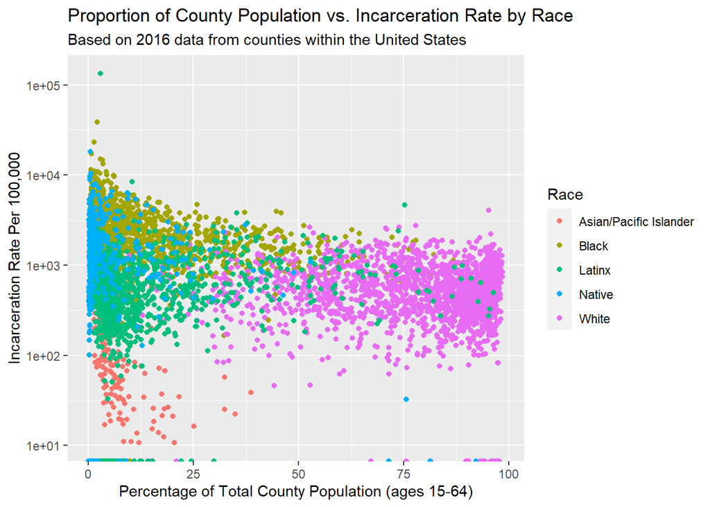

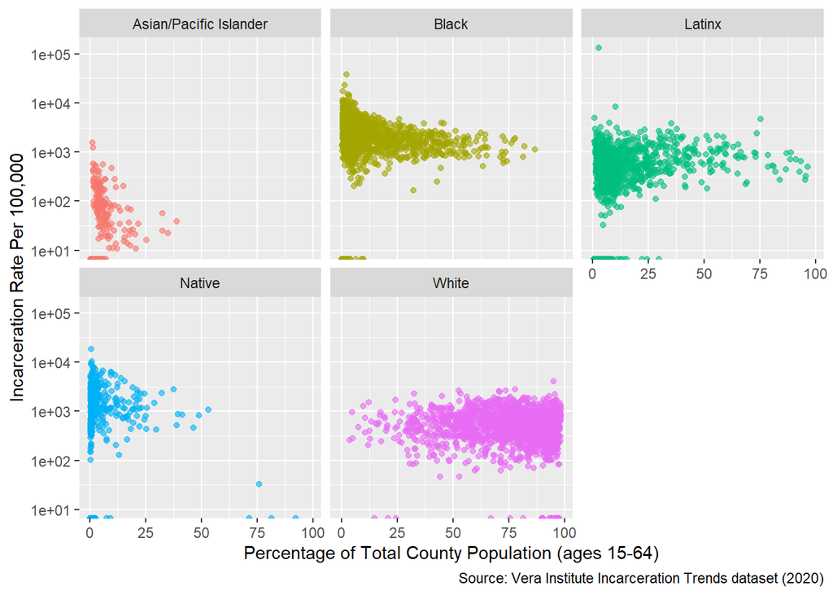

#### Part IV. Map

This map compares the median difference in Black and White incarceration rates for each state in 2016 (subtracting Black incarceration rate by White incarceration rate). I decided to include this comparison to visualize how the discrepancy in Black and White incarceration varies geographically. I chose to use the median rather than the mean in this chart to minimize the effect of outlier county data. Each state is colored on a spectrum from purple (lowest median difference) to yellow (highest median difference), but states without data are shaded in gray. In general, we can observe that most of the northwestern states show low differences between the two incarceration rates, whereas the mid-west and eastern states have greater differences. The state with the highest median difference is Utah, showing a median difference of over 3,000 Blacks incarcerated over Whites per 100,000. This is disturbing because according to 2016 U.S. census data, Blacks only represent about 1% of the population there whereas Whites make up nearly 80% of their population. Furthermore, we can also see that there are no negative differences present in this map, which implies that no state in 2016 had a higher incarceration rate for Whites than Blacks even when Whites make up the majority in every state.

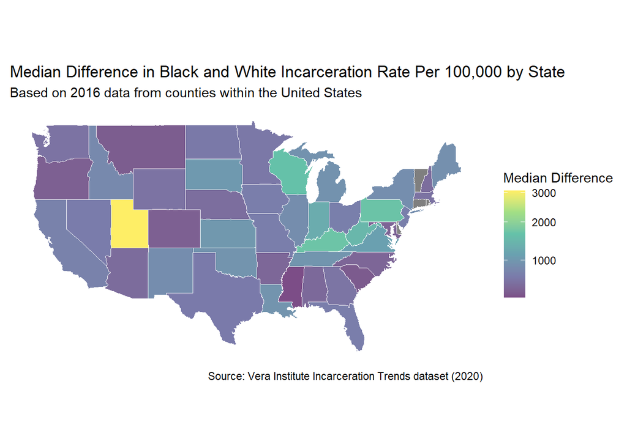